# ChemAnalysis Workbench

ChemAnalysis Workbench (CAW) is based on an Eclipse rich client platform (RCP), and written in java programming language. It is a highly modular platform with an extensible design. The Eclipse environment has proven to be a very robust system, and is extensively used by organizations such as IBM, SAP, NASA as a framework for their software applications.

CAW is intended to be used with our Mod-Spec line of instruments however, each functionality in eclipse is developed and deployed as a separate addition called a “plugin” and this allows anyone to quickly adapt CAW for a custom application in case its not supported by default.

CAW has a data acquisition layer, where it reads data from an instrument’s electronics through USB port; a data visualization layer, which plots the data, and a data analysis layer which provides scripting support using python and R for advanced data analysis. ChemAnalysis also comes with default scripts to run the commonly used data analysis and statistical functions. All of this is packaged as a graphical user interface for a user friendly experience.

## Installation

### Standalone application

ChemAnalysis Workbench v1.1 binaries (32 bit, 64 bit) are available to download as a .zip file at Github. The current release of CAW requires Java 1.6.0 or higher be installed on your computer. To verify it:

- Open a command window and enter java -version
- Your Java run-time will respond with something like “1.8.0_20”.
- Close your command window.

Create a new folder or directory. Name it “ChemAnalysis Workbench” or some else.

- Drag the downloaded .zip file from your downloads area into this new directory.
- Extract everything from the compressed .zip file.
- click on the .exe file to launch CAW.

### DAWN perspective application

The standalone application works fine in case the user only wants to acquire data and perform all the advanced calculations on their preferred spreadsheet program like MS Excel, libre office Calc etc.

However, some advanced users prefer to programmatically perform calculations using powerful programming languages such as R, python and, ofcourse, java. We have packaged CAW for specifically such a user case, and via this version, the user can install in via an update site.

- Download DAWN version 2.3.1 from http://dawnsci.org/downloads/
- Switch workplace by ging to File>switch Workplace to a new empty folder, named “ChemAnalysis Workbench” or some else.
- Go to Help>install new software.
- Enter the following url https://github.com/jaypat87/chemanalysis-updatesite-1/raw/master/latest on the box labeled “work with” and click “add”.
- unclick the “group items by category” button
- Tick yes to the “Chem Analysis Feature”
- Click next on the subsequent steps until CAW is installed as a perspective
- Click on the change perspective, and select CAW to launch the application

## Description

### Overview

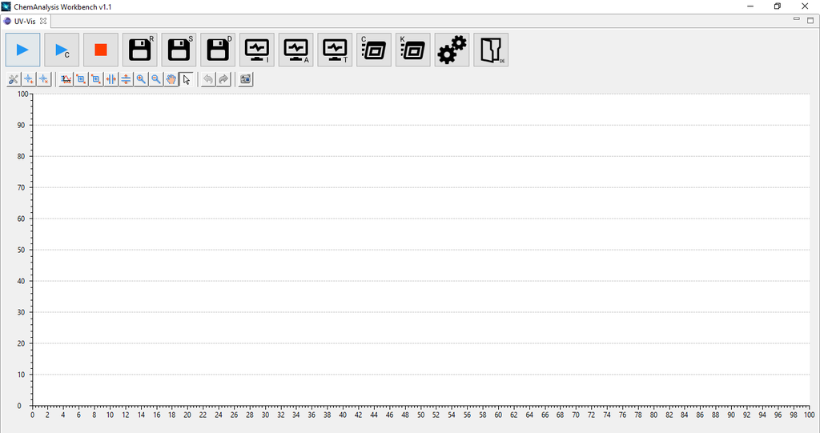

Figure 3.1: Front Panel for the CAW standalone application.

### Settings Window

[figure not shown]

[figure not shown]

### Intensity Mode

Intensity mode is the default mode for CAW. The x-axis is pixels, and y-axis reads the relative intensity as a count of number of photons hitting the detector for a given integration time.

### Absorbance mode

Absorbance is defined as amount of light absorbed by the sample compared to the reference (or blank) spectra. The x-axis is wavelength in microns or nm as selected in the settings window, the y-axis shows absorbance, as calculated below:

Absorbanceλ = – Log10 [ (Sλ – Dλ)/(Rλ – Dλ) ]

where:

Sλ = Sample intensity at wavelength λ  
Dλ = Dark intensity at wavelength λ  
Rλ = Reference intensity at wavelength λ

### Transmittance mode

Transmittance is defined as percentage of light transmitted through the sample compared to light transmitted through the reference. The x-axis is wavelength in microns or nm as selected in the settings window, the y-axis shows % transmittance as calculated below:

% Transmittanceλ = [ (Sλ – Dλ)/(Rλ – Dλ) ] x 100

where:

Sλ = Sample intensity at wavelength λ  
Dλ = Dark intensity at wavelength λ  
Rλ = Reference intensity at wavelength λ

### Concentration mode

Beer-Lambert law states that absorbance is directly proportional to the concentration of the analyte species. Using this relationship, the y-axis units are changed to molarity. The equation can be shown below:

A = ε*c*l

where,

A = Absorbance at a wavelength λ  
ε = wavelength dependent molar absorptivity coefficient, typically reported for λmax  
c = concentration (in molarity)  
l = path length of the cuvette (typically equal to 1 cm)

In case ε is not available for a particular analyte, than it can be easily calculated from a regression line obtained by taking readings for atleast three samples of known concentration. These calculations can be easily performed in the jython perspectives in DAWN, or though Stat-ET using R.

### Kinetics mode

Reaction kinetics can be monitored by measuring absorbance over time. In this mode, The x-axis is time (in mins), and y-axis is absorbance. Typically, kinetics is performed only at λmax wavelength; however, a range of wavelengths can be monitored by changing the range in the settings window. The sampling rate can also be changed through settings window, though we recommend a value of 0.3 minutes. Kinetics measurements are initiated via the continuous spectrum acquisition button instead of single spectrum acquisition used for all the other modes.

### DExplore mode

This is the data explorer mode which lets the user browse saved spectra files on the working directory. When CAW is launched on a computer the first time, the user has to set up its working directory.

Right click anywhere on the empty Project Explorer pane, and click New>Project

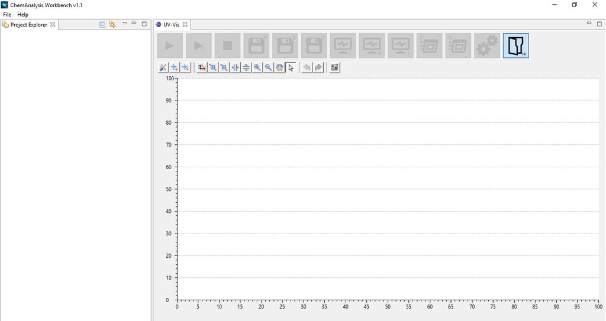

Select Project, and click Next

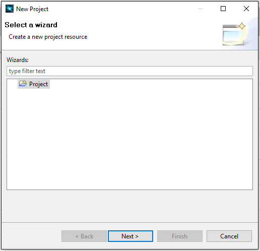

Name the project accordingly, and change the default location of the workspace folder if needed.

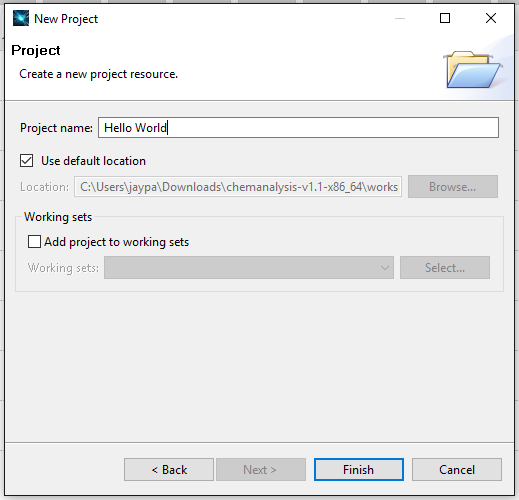

Once, a new project is created, spectrum files can be saved in that folder. Also, files can be directly copied in the project folder

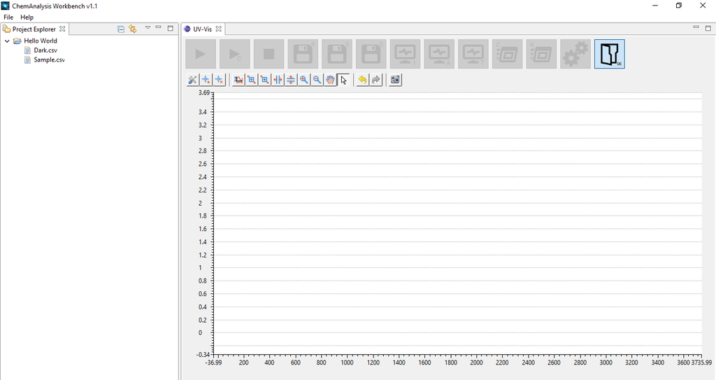

Spectra could be plotted by double clicking the files. In case the user wants to change the default settings, than right click, and select “open with” to select another plotting programs available in DAWN workspace.

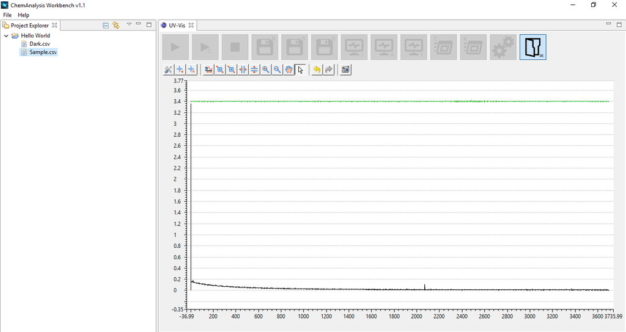

## Download

- [Click here](https://github.com/jaypat87/chemanalysis-updatesite-1/tree/master/binary) to download the ChemAnalysis Workbench binaries for 32/64 bit.
- [Click here](https://github.com/jaypat87/chemanalysis-1) for source code repo.